# Peso al destete *Mirounga leonina*, Isla 25 de Mayo

Datos del Instituto Antartico Argentino  
Dr. Javier Negrete  
Enviados por Malena Pfoh

Todos los analisis estan en esta direccion  
https://github.com/adbpatagonia/MLPesoCachorros

# Relacion de peso al destete con eventos de El Nino

Malena envio datos de peso al destete de cachorros de *Mirounga leonina* y de potencia del ENSO para distintaas epocas del ano.  
Estas exploraciones fueron realizadas con la potencia media de marzo a agosto.

## ENSO como medida discreta

Se definio a eventos de ENSO de la siguiente manera:

- Nina: ENSO <= -0.5
- Neutro: -0.5 < ENSO < 0.5
- Nino: ENSO => 0.5

Modelo lineal general (i.e. ANOVA de 2 vias):

Peso al Destete ~ ENSO + sexo + ENSO * sexo,

donde ENSO * sexo representa la interaccion entre ENSO y sexo del cachorro

Tabla de ANOVA para el modelo lineal incluyendo interaccion

|  | Df | Sum Sq | Mean Sq | F value | Pr(>F) |
| --- | --- | --- | --- | --- | --- |
| evento.ma | 2 | 18151.263 | 9075.6313 | 12.416310 | 0.0000045 |
| sexo | 1 | 40487.419 | 40487.4188 | 55.390566 | 0.0000000 |
| evento.ma:sexo | 2 | 3096.477 | 1548.2383 | 2.118134 | 0.1206134 |
| Residuals | 1508 | 1102264.009 | 730.9443 | NA | NA |

La interaccion no es significativa (p-value = 0.121)  
Entonces, descartarla y continuar solo con los efectos principales

Tabla de ANOVA para el modelo lineal excluyendo interaccion

|  | Df | Sum Sq | Mean Sq | F value | Pr(>F) |
| --- | --- | --- | --- | --- | --- |
| evento.ma | 2 | 18151.26 | 9075.6313 | 12.39795 | 4.6e-06 |
| sexo | 1 | 40487.42 | 40487.4188 | 55.30866 | 0.0e+00 |
| Residuals | 1510 | 1105360.49 | 732.0268 | NA | NA |

Ambos efectos principales son significativos a un nivel de $alpha$ de 5%.

Valores de los parametros del ANOVA de 2 vias (con intervalo de confianza del 95%):

|  | paramvalue | X2.5.. | X97.5.. |
| --- | --- | --- | --- |
| (Intercept) | 158.887577 | 155.168576 | 162.606579 |
| evento.maNeutro | -7.381559 | -11.205092 | -3.558025 |
| evento.maNiño | -12.772576 | -17.818687 | -7.726464 |
| sexoMacho | 10.345465 | 7.616802 | 13.074127 |

Es decir,  
* en promedio los machos pesan 10 kg mas que las hembras  
* en promedio, en anos neutros los cachorros pesan 7.4 kg menos que en anos de nina  
* en promedio, en anos de nino los cachorros pesan 12.8 kg menos que en anos de nina

Intercept es el valor para hembras en anos nina  
Para obtener el valor apra hembras en anos neutros, tenes que sumar Intercept + evento.maNeutro, es decir: 158.887577 - 7.381559 = 151.506  
Para obtener el valor apra hembras en anos nino, tenes que sumar Intercept + evento.maNino, es decir: 158.887577 - 12.772576 = 146.115  
Para obtener el valor apra machos en anos nina, tenes que sumar Intercept + sexoMacho, es decir: 158.887577 + 10.345465 = 169.233  
Para obtener el valor apra machos en anos neutro, tenes que sumar Intercept + sexoMacho + evento.maNeutro, es decir: 158.887577 + 10.345465 - 7.381559 = 161.8515  
Para obtener el valor apra machos en anos nina, tenes que sumar Intercept + sexoMacho + evento.maNino, es decir: 158.887577 + 10.345465 - 12.772576 = 156.4605

### Pirate Plot

EN este grafico se visualizan 4 elementos:

1. datos (puntos)
2. distribucion de los datos (violin plot)
3. medida de tendencia central (linea negra)
4. intervalo de inferencia, en este caso 95% Bayesian Highest Density Interval. Si los intervalos se solapan, las diferencias no son significativas, y lo son si estos no se solapan.

Para una descripcion completa de este tipo de graficos, mirar aca  
https://cran.r-project.org/web/packages/yarrr/vignettes/pirateplot.html

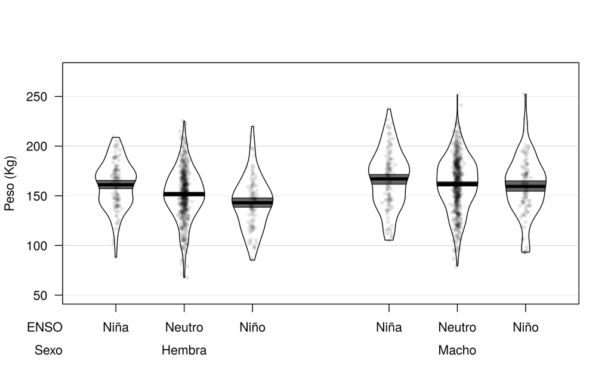

Estos son los valores que definen a este grafico

| summary.evento.ma | summary.sexo | summary.bean.num | summary.n | summary.avg | summary.inf.lb | summary.inf.ub | avg.line.fun | inf.method | inf.p |
| --- | --- | --- | --- | --- | --- | --- | --- | --- | --- |
| Niña | Hembra | 1 | 118 | 161.0847 | 157.1317 | 165.3624 | mean | hdi | 0.95 |
| Neutro | Hembra | 2 | 521 | 151.6192 | 149.3343 | 153.8959 | mean | hdi | 0.95 |
| Niño | Hembra | 3 | 102 | 142.9951 | 138.2814 | 148.2131 | mean | hdi | 0.95 |
| Niña | Macho | 4 | 117 | 167.0171 | 161.4769 | 172.2256 | mean | hdi | 0.95 |
| Neutro | Macho | 5 | 549 | 161.7441 | 159.5576 | 164.1045 | mean | hdi | 0.95 |
| Niño | Macho | 6 | 107 | 159.4346 | 152.3585 | 164.5717 | mean | hdi | 0.95 |

Los valores de esta tabla no coinciden perfectamente con los parametros del ANOVA xq se obtuvieron x diferentes metodos, pero son consistentes.

## ENSO como medida continua

explore utilizar los datos de ENSO como medida continua, en lugar de caracterizarlo como Nina, Neutro, Nino

Modelo lineal general  
Peso al Destete ~ ENSO + sexo + ENSO * sexo,

como en este caso ENSO es continuo, esto se llama ANCOVA (1 variable independiente continua 1 una discreta)

Tabla de ANOVA para el modelo lineal incluyendo interaccion

|  | Df | Sum Sq | Mean Sq | F value | Pr(>F) |
| --- | --- | --- | --- | --- | --- |
| potencia.mar.agos | 1 | 9975.375 | 9975.3751 | 13.546243 | 0.0002409 |
| sexo | 1 | 40312.953 | 40312.9534 | 54.743712 | 0.0000000 |
| potencia.mar.agos:sexo | 1 | 1755.556 | 1755.5559 | 2.383989 | 0.1227937 |
| Residuals | 1510 | 1111955.283 | 736.3942 | NA | NA |

*acalaracion:* en la tabla de ANOVA la variable ENSO aparace como “potencia.mar.agos”

La interaccion no es significativa (p-value = 0.123)  
Entonces, descartarla y continuar solo con los efectos principales

Tabla de ANOVA para el modelo lineal excluyendo interaccion

|  | Df | Sum Sq | Mean Sq | F value | Pr(>F) |
| --- | --- | --- | --- | --- | --- |
| potencia.mar.agos | 1 | 9975.375 | 9975.3751 | 13.53385 | 0.0002425 |
| sexo | 1 | 40312.953 | 40312.9534 | 54.69362 | 0.0000000 |
| Residuals | 1511 | 1113710.839 | 737.0687 | NA | NA |

Ambos efectos principales son significativos a un nivel de $alpha$ de 5%.

|  | paramvalue | X2.5.. | X97.5.. |
| --- | --- | --- | --- |
| (Intercept) | 151.536218 | 149.568467 | 153.503968 |
| potencia.mar.agos | -6.556128 | -9.999169 | -3.113086 |
| sexoMacho | 10.322836 | 7.584877 | 13.060794 |

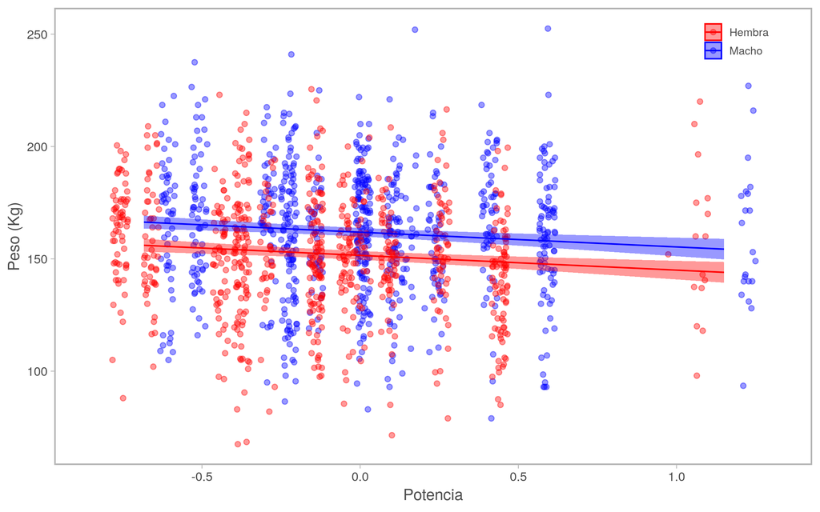